# Nonprofit Story

Author

Trey Roark

# Overview

Through analysis already done by Trey Roark and Amelia Baier with the data at the IRS, we’ll create a summary of what we believe to be the most important metrics and statistics of interest that we’d like to include in our dashboard. Additionally, we’ll visualize these metrics and expand upon how we best believe they can be used to help our use cases.

This will include both the data itself, as well as different ways to visualize a lot of these metrics, so our dashboard will contain a nice pipeline that will end up being easy to use.

For more information on the data and it’s preprocessing, please look here: https://theundivideproject.github.io/Philanthropic-Giving-Analysis.github.io/

# EOMBF Findings

Looking at the Exempt Organizations Business Master File (EO BMF), which is pulled from the Internal Revenue Service’s Business Master File, provides some features that can be used for a detailed analysis of philanthropic giving, particular within the environmental and social justice sectors.

Right now, we’re just looking specifically at the Northeast (inclusive of Connecticut, Maine, Massachusetts, New Hampshire, New Jersey, New York, Rhode Island, Vermont). This data can be found here https://www.irs.gov/charities-non-profits/exempt-organizations-business-master-file-extract-eo-bmf

## Preliminary Statistics (Subject to Change)

```
266754
```

As of 10/14/2024 in the Northeast quadrant, there are currently 266,754 tax exempt organizations, logged through the IRS’ database.

## Temporal Display of Tax Exempt Organizations

In the figure below, we can see the timeline of organizations receiving their tax exempt status. First, there’s been quite an increase in these organizations in the past 10 years.

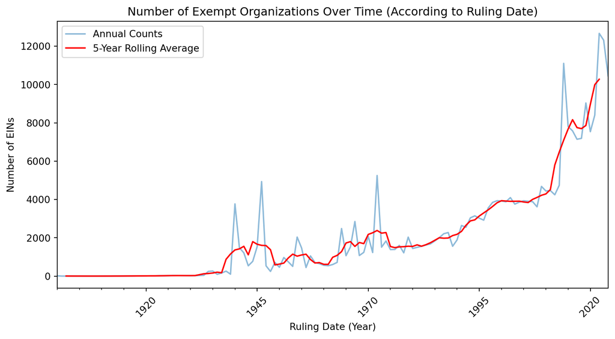

## Geographic Display of our Tax Exempt Organizations

We can see a representation of these organization’s headquarters by count in each state below. (For potential regional focuses and gaps in support identification)

[interactive chart not shown]

Figure 1: Geographic Analysis of Northeast Exempt Organizations

[figure not shown]

## Look at the dashboard above we gain a couple of insights: